# This is just the scratchpad for the analysis not the final report

Ozan Aygun

5/7/2017

Load the data sets:

```r
training <- read.csv("train.csv", stringsAsFactors = FALSE, na.strings = "")
testing <- read.csv("test.csv", stringsAsFactors = FALSE,na.strings = "")
```

Partition the training set into:

- training: train different models
- tune.test.set: initial out of the box performance

```r
library(caret)
set.seed(1234)
InTrain <- createDataPartition(y=training$Survived,p = 0.7,list = FALSE)

tune.test.set <- training[-InTrain,]
training <- training[InTrain,]
```

Summarize the training data set:

```r
summary(training)
```

```
##   PassengerId       Survived         Pclass          Name
##  Min.   :  1.0   Min.   :0.000   Min.   :1.000   Length:624
##  1st Qu.:232.5   1st Qu.:0.000   1st Qu.:2.000   Class :character
##  Median :450.5   Median :0.000   Median :3.000   Mode  :character
##  Mean   :448.5   Mean   :0.383   Mean   :2.303
##  3rd Qu.:663.2   3rd Qu.:1.000   3rd Qu.:3.000
##  Max.   :891.0   Max.   :1.000   Max.   :3.000
##
##      Sex                 Age            SibSp            Parch
##  Length:624         Min.   : 0.75   Min.   :0.0000   Min.   :0.0000
##  Class :character   1st Qu.:21.00   1st Qu.:0.0000   1st Qu.:0.0000
##  Mode  :character   Median :28.50   Median :0.0000   Median :0.0000
##                     Mean   :29.92   Mean   :0.5096   Mean   :0.3782
##                     3rd Qu.:38.50   3rd Qu.:1.0000   3rd Qu.:0.0000
##                     Max.   :80.00   Max.   :8.0000   Max.   :5.0000
##                     NA's   :129
##     Ticket               Fare            Cabin
##  Length:624         Min.   :  0.000   Length:624
##  Class :character   1st Qu.:  7.896   Class :character
##  Mode  :character   Median : 14.458   Mode  :character
##                     Mean   : 31.219
##                     3rd Qu.: 31.621
##                     Max.   :512.329
##
##    Embarked
##  Length:624
##  Class :character
##  Mode  :character
##
##
##
##
```

```r
table(training$Sex)
```

```
##
## female   male
##    216    408
```

```r
table(training$Cabin)
```

```
##
##             A10             A14             A16             A20
##               1               1               1               1
##             A23             A24             A26             A34
##               1               1               1               1
##             A36              A5              A7            B101
##               1               1               1               1
##            B102             B18             B19             B20
##               1               1               1               2
##             B22             B28             B30             B35
##               2               1               1               2
##             B37             B38             B39              B4
##               1               1               1               1
##             B41             B49              B5             B50
##               1               1               2               1
##     B51 B53 B55 B57 B59 B63 B66             B77             B79
##               1               1               2               1
##         B82 B84             B86             B94         B96 B98
##               1               1               1               3
##            C101            C103            C104            C106
##               1               1               1               1
##            C110            C111            C123            C124
##               1               1               2               1
##            C125            C126            C148              C2
##               2               2               1               2
##         C22 C26     C23 C25 C27             C32             C46
##               2               2               1               1
##             C47             C49             C50             C52
##               1               1               1               1
##         C62 C64             C65             C68              C7
##               1               2               2               1
##             C78             C82             C83             C85
##               2               1               2               1
##             C86             C87             C90             C91
##               1               1               1               1
##             C92             C93             C95               D
##               2               2               1               2
##         D10 D12             D11             D15             D17
##               1               1               1               1
##             D19             D20             D21             D26
##               1               1               1               1
##             D28             D33             D35             D36
##               1               2               2               2
##             D45             D49             D50             D56
##               1               1               1               1
##              D6              D7              D9            E101
##               1               1               1               3
##             E12            E121             E17             E24
##               1               2               1               1
##             E25             E31             E33             E34
##               1               1               1               1
##             E36             E38             E40             E49
##               1               1               1               1
##             E50             E58             E63             E67
##               1               1               1               2
##             E68              E8           F E69           F G63
##               1               1               1               1
##           F G73              F2             F38              F4
##               1               2               1               2
##              G6
##               3
```

```r
table(training$Embarked)
```

```
##
##   C   Q   S
## 122  51 450
```

# Basic preprocessing and EDA (all processing performed in the building set and exactly applied to tune.testing,validation, and final_testing sets)

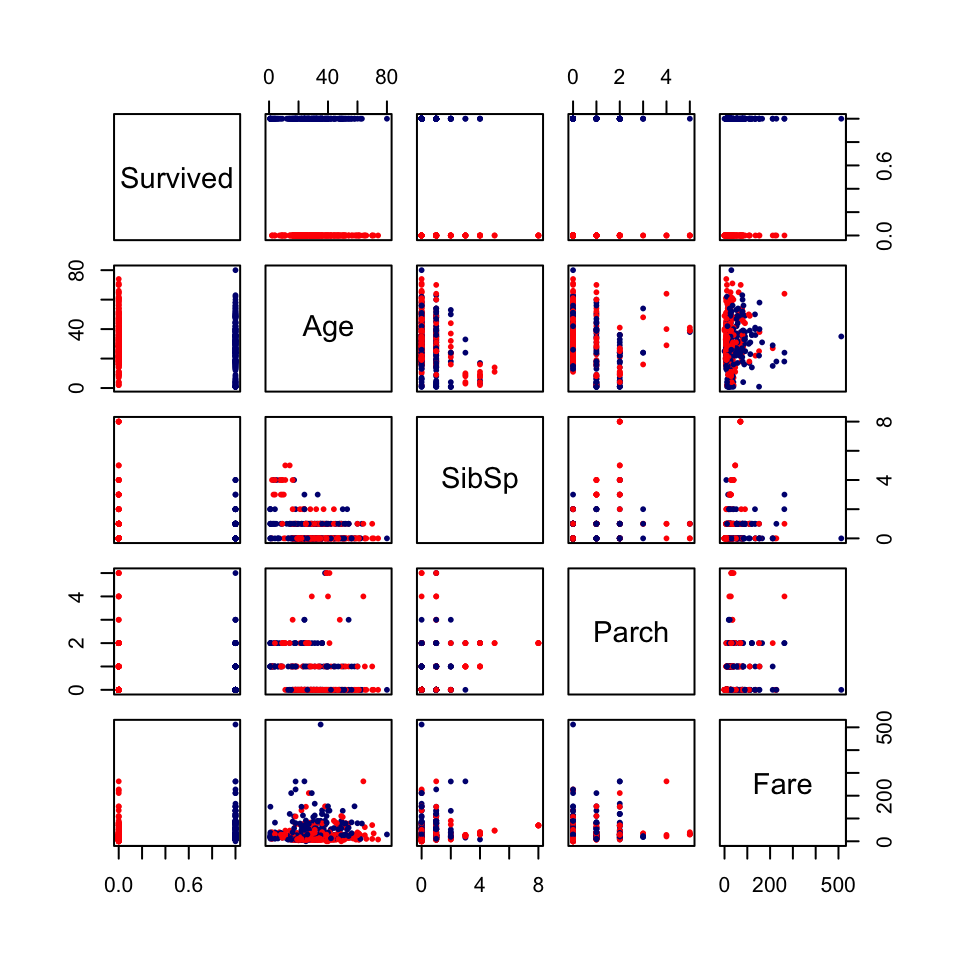

```r
#Exploration by pairs plot:
pairs(Survived ~ Age+ SibSp+Parch+Fare,pch =19, cex = 0.4,data=training,
      col= ifelse(training$Survived == 1, "navy","red"))
```

```r
# Clearly less people survived from the 3rd class
table(training$Survived,training$Pclass)
```

```
##
##       1   2   3
##   0  56  69 260
##   1  97  60  82
```

```r
table(training$Survived, training$Embarked)
```

```
##
##       C   Q   S
##   0  59  31 295
##   1  63  20 155
```

```r
# Clearly more Females survived
table(training$Survived,training$Sex)
```

```
##
##     female male
##   0     52  333
##   1    164   75
```

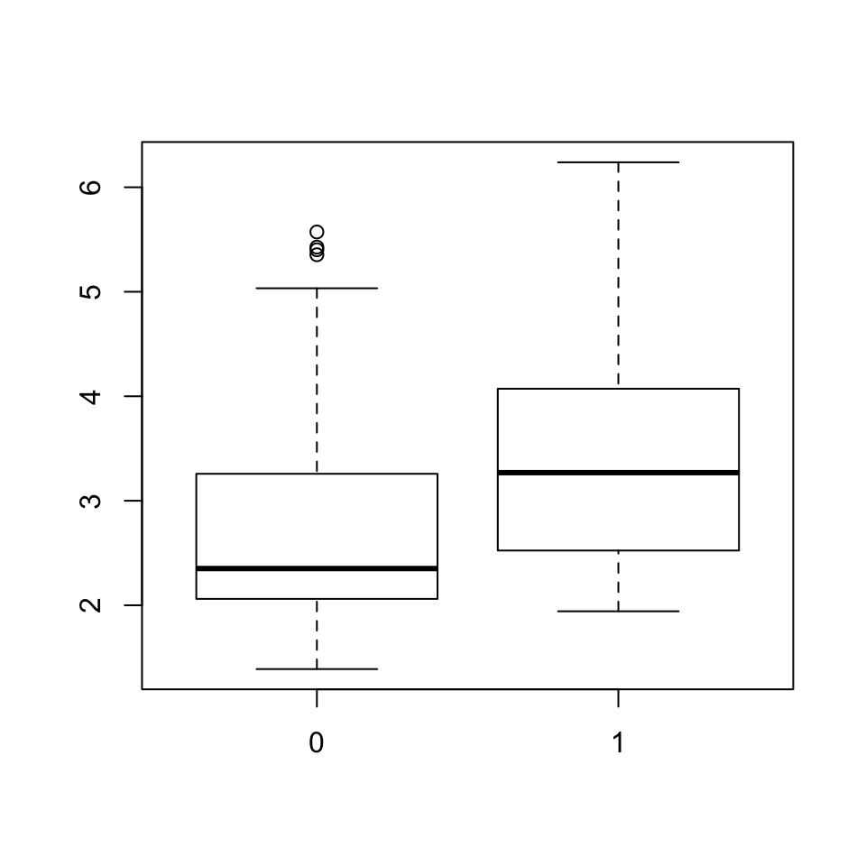

```r
# Consistent with the Class ~ Survival relationship
boxplot(log(Fare) ~ Survived, data = training)
```

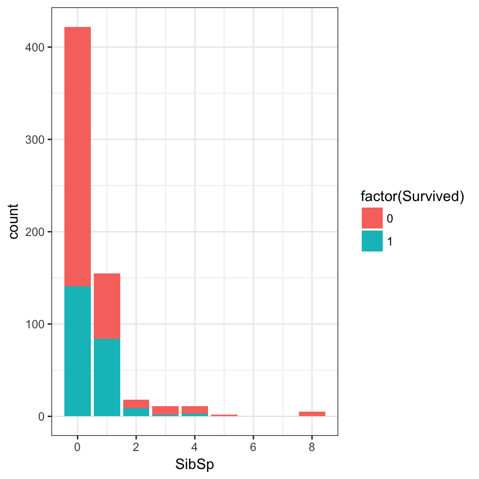

```r
library(ggplot2)
ggplot(aes(x = SibSp, fill = factor(Survived)), data = training)+
        geom_bar(stat = "count")+
        theme_bw()
```

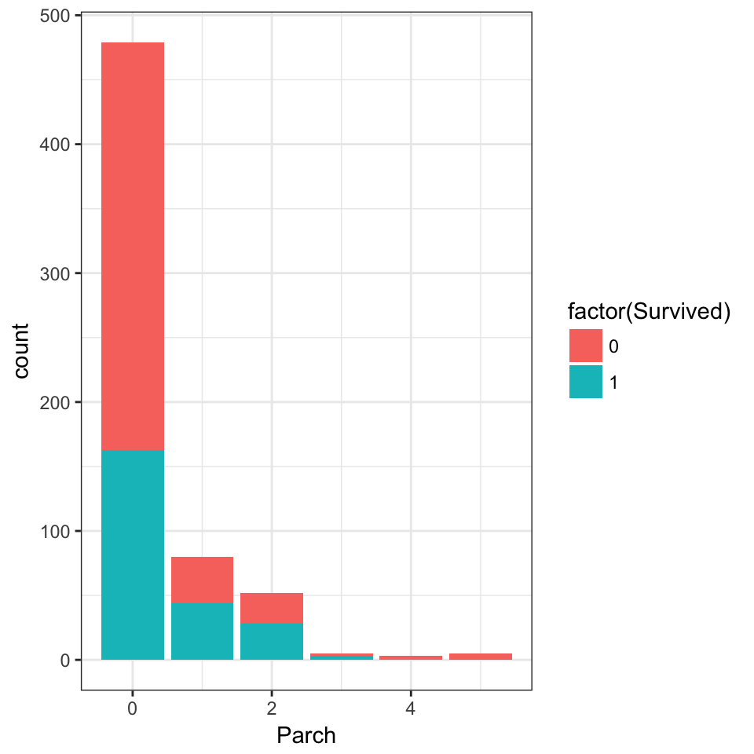

```r
ggplot(aes(x = Parch, fill = factor(Survived)), data = training)+
        geom_bar(stat = "count")+
        theme_bw()
```

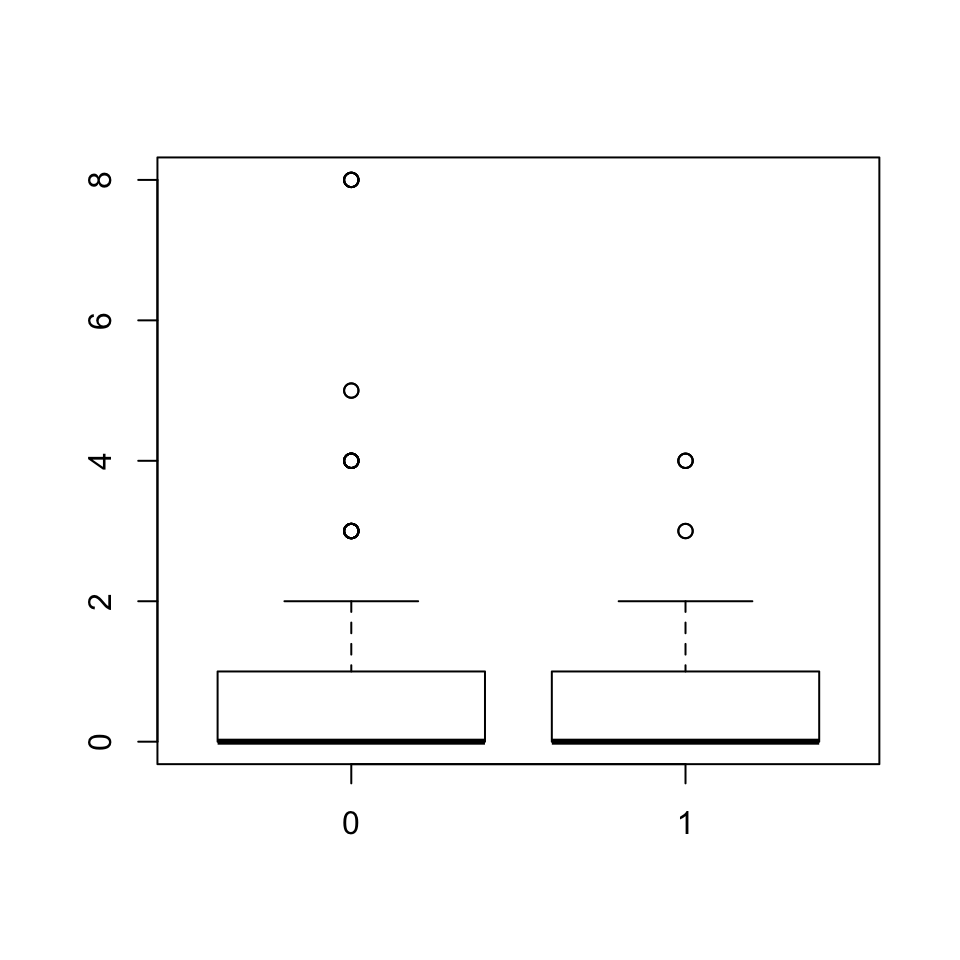

```r
boxplot(SibSp ~ Survived, data = training)
```

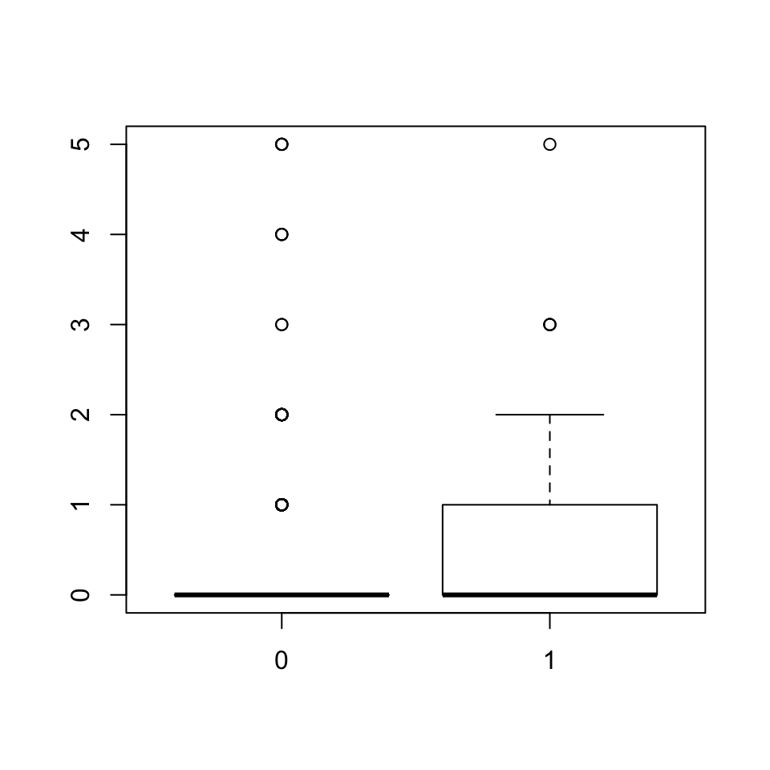

```r
boxplot(Parch ~ Survived, data = training)
```

## Generate factor (categorical variables)

```r
training <- transform(training,Survived = factor(Survived), Pclass = factor(Pclass),
          Sex = factor(Sex),SibSp = factor(SibSp), Parch = factor(Parch), Embarked = factor(Embarked))
tune.test.set <- transform(tune.test.set,Survived = factor(Survived), Pclass = factor(Pclass),Sex = factor(Sex),SibSp = factor(SibSp), Parch = factor(Parch), Embarked = factor(Embarked))

testing <- transform(testing, Pclass = factor(Pclass),
          Sex = factor(Sex),SibSp = factor(SibSp), Parch = factor(Parch), Embarked = factor(Embarked))
```

## Remove the passenger ID column from the training sets.

```r
library(dplyr)
training <- dplyr::select(training,-PassengerId)
tune.test.set <- dplyr::select(tune.test.set,-PassengerId)
```

# Investigate the missing values

```r
training.na <- as.data.frame(is.na(training));names(training.na) <- names(training)
apply(training.na,2,sum)
```

```
## Survived   Pclass     Name      Sex      Age    SibSp    Parch   Ticket
##        0        0        0        0      129        0        0        0
##     Fare    Cabin Embarked
##        0      476        1
```

Missing values appear in 3 variables; Age, Cabin and Embarked.

### Cabin feature: more than 75% is missing

From the available observations, we can infer that the first letter actually presents the cabin section.

Extract the first letter from the available ones and test if they have any predictive value:

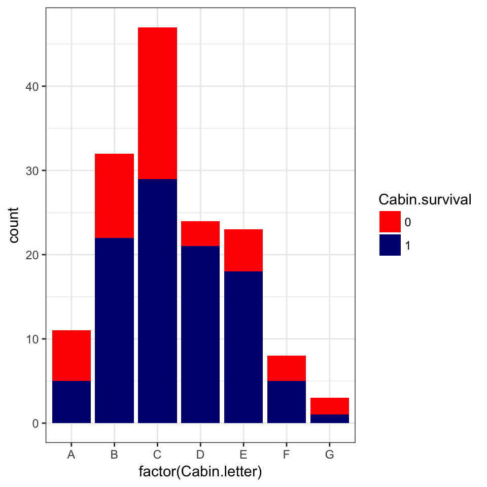

```r
library(ggplot2); library(dplyr)
Cabin.letter <-substr(training$Cabin[!training.na$Cabin],1,1)
Cabin.survival <- training$Survived[!training.na$Cabin]
Cabin.Pclass <- training$Pclass[!training.na$Cabin]
qplot(x = factor(Cabin.letter), fill = Cabin.survival)+scale_fill_manual(values = c("red","navy"))+theme_bw()
```

We notice that this feature has some predictive value.

We check if the cabin relates with the Pclass:

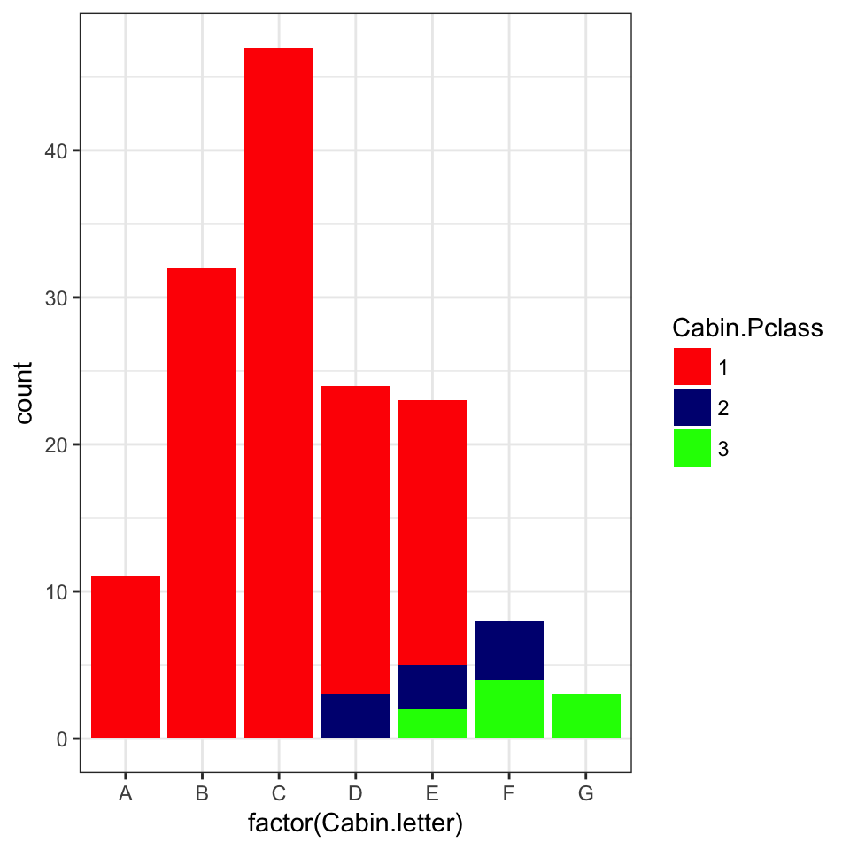

```r
qplot(x = factor(Cabin.letter), fill = Cabin.Pclass)+scale_fill_manual(values = c("red","navy","green"))+theme_bw()
```

We indeed notice that Cabin letters A,B,C are absolutely first class and therefore can be inferred from the Pclass variable. D and E are also more likely to be in 1st class. Gs are all coming from the 3rd Class.

We can also check if fare relates with the cabin letter:

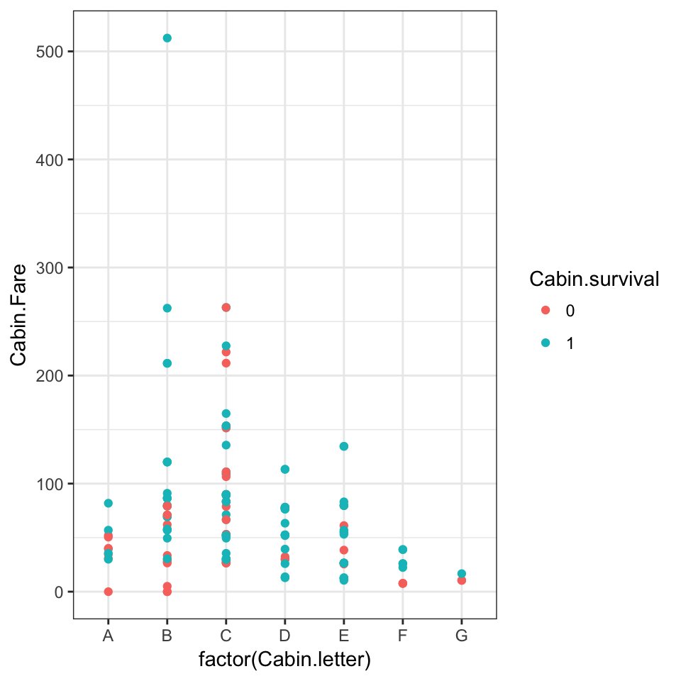

```r
Cabin.Fare <- training$Fare[!training.na$Cabin]
qplot(x = factor(Cabin.letter), y=Cabin.Fare, color = Cabin.survival)+theme_bw()
```

The relationship between Fare and Cabin Letter is not so dramatic to allow some imputation.

The problem with imputing Cabin feature from Pclass is that we don’t know whether the missing variables are MCAR (Missing Completely at Random) or whether there is a relationship between the reason they are missing and the outcome (Survival).

Therefore, it would be more sensible to drop this variable and don’t use in building our classifiers.

#### Remove Cabin feature from all sets:

```r
training <- dplyr::select(training, - Cabin)
tune.test.set <- dplyr::select(tune.test.set, -Cabin)
testing <- dplyr::select(testing, -Cabin)
```

## Age feature: ~ 20% missing data

One intuitive imputation potential could be comparing the Age with SibSp feature:

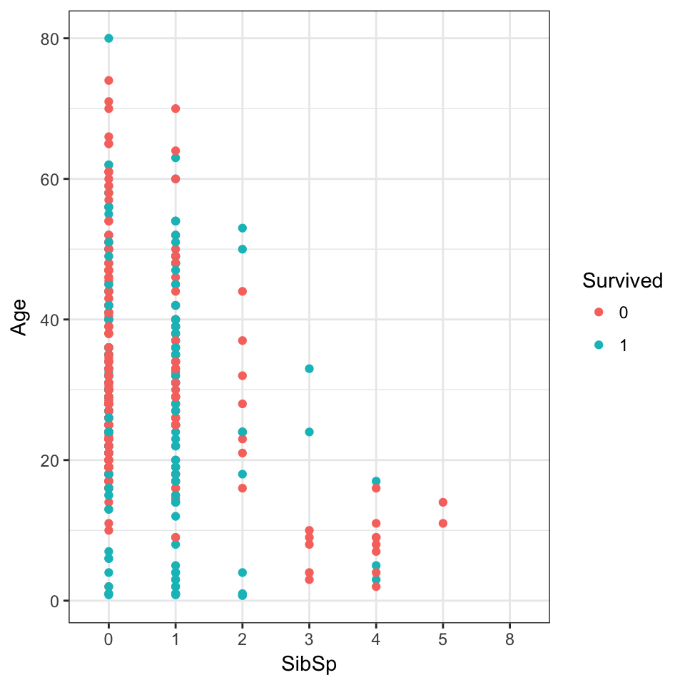

```r
qplot(x = SibSp, y = Age, color = Survived, data = training)+
       theme_bw()
```

We notice that as the SibSp increases, the age group decreases.

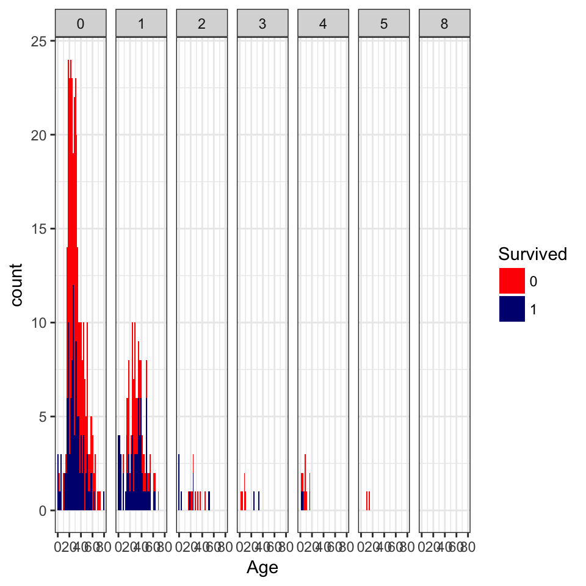

```r
ggplot(data = training, aes(x = Age, fill= Survived))+
        geom_histogram(bins = 40)+facet_grid(. ~ SibSp)+ scale_fill_manual(values = c("red","navy"))+
        theme_bw()
```

Most of the Age distribution is having either no Spouses or siblings or only 1. For the 1 siblings/spouses group the mean age is higher. In both cases Age is appromated by normal distribution. The problem with SibSp is that some of the factor levels are only present in the observations where Age is missing, making this predictor unbalanced across the missing and complete cases.

It would be also interesting to explore gender differences when considering Age:

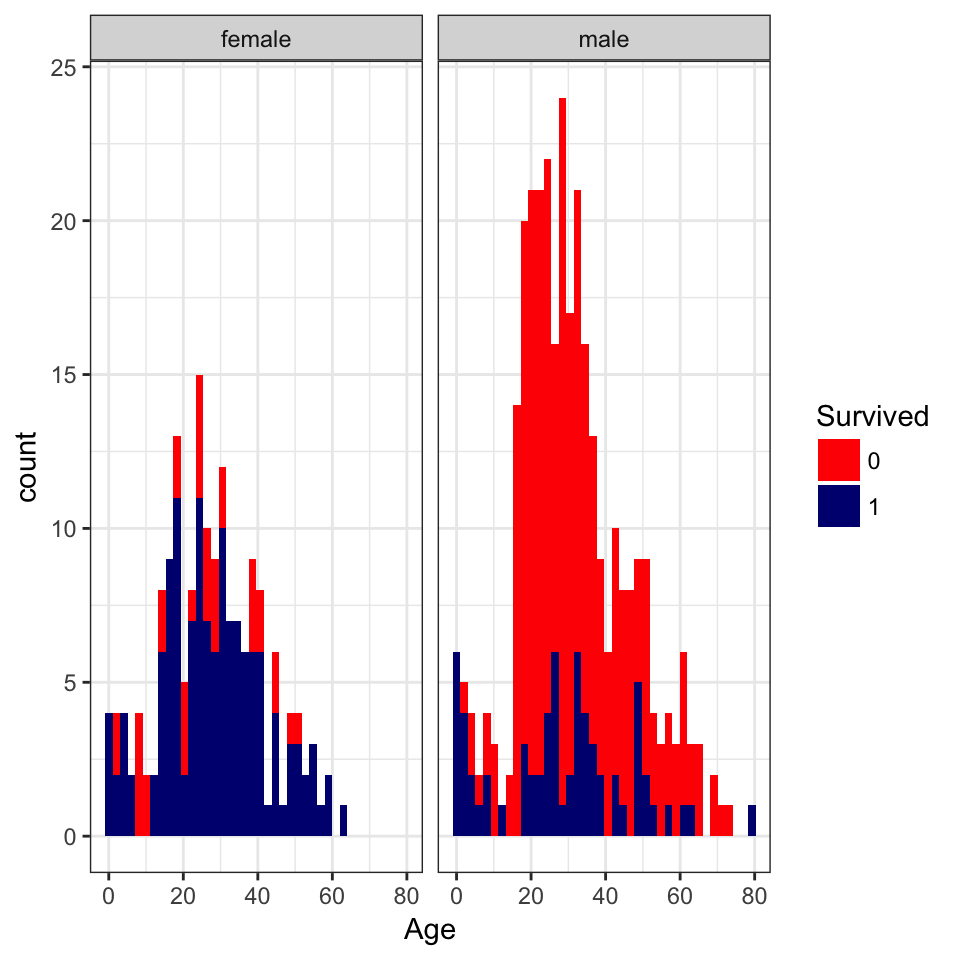

```r
ggplot(data = training, aes(x = Age, fill= Survived))+
        geom_histogram(bins = 40)+facet_grid(. ~ Sex)+ scale_fill_manual(values = c("red","navy"))+
        theme_bw()
```

How about the Age distribution in different passenger classes? (Pclass):

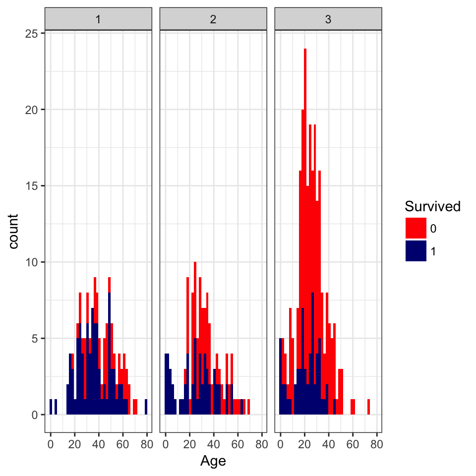

```r
ggplot(data = training, aes(x = Age, fill= Survived))+
        geom_histogram(bins = 40)+facet_grid(. ~ Pclass)+ scale_fill_manual(values = c("red","navy"))+
        theme_bw()
```

```r
training %>% group_by(Pclass,Survived) %>% summarise(mean(Age,na.rm=T))
```

```
## Source: local data frame [6 x 3]
## Groups: Pclass [?]
##
##   Pclass Survived `mean(Age, na.rm = T)`
##   <fctr>   <fctr>                  <dbl>
## 1      1        0               44.65217
## 2      1        1               35.49907
## 3      2        0               34.51587
## 4      2        1               24.91509
## 5      3        0               26.52174
## 6      3        1               20.83898
```

This is quite interesting! In all passenger classes, the mean age of the survived passengers is lower than those passed away. We also notice that the mean age decreases and the Class number increases, i.e: older passengers are in the better classes on average. Therefore, Pclass would also be include in the imputation model.

##### Age ~ Sex + Pclass + e (random gaussian error)

```r
lmAge = lm(Age ~ Sex + Pclass, data = training, na.action = "na.omit")
summary(lmAge)
```

```
##
## Call:
## lm(formula = Age ~ Sex + Pclass, data = training, na.action = "na.omit")
##
## Residuals:
##     Min      1Q  Median      3Q     Max
## -40.261  -8.119  -0.634   7.819  47.366
##
## Coefficients:
##             Estimate Std. Error t value Pr(>|t|)
## (Intercept)   35.605      1.339  26.600  < 2e-16 ***
## Sexmale        5.577      1.257   4.436 1.13e-05 ***
## Pclass2       -8.949      1.658  -5.397 1.06e-07 ***
## Pclass3      -14.548      1.439 -10.112  < 2e-16 ***
## ---
## Signif. codes:  0 '***' 0.001 '**' 0.01 '*' 0.05 '.' 0.1 ' ' 1
##
## Residual standard error: 13.14 on 491 degrees of freedom
##   (129 observations deleted due to missingness)
## Multiple R-squared:  0.1838, Adjusted R-squared:  0.1788
## F-statistic: 36.86 on 3 and 491 DF,  p-value: < 2.2e-16
```

```r
par(mfrow = c(2,2))
plot(lmAge)[1]
```

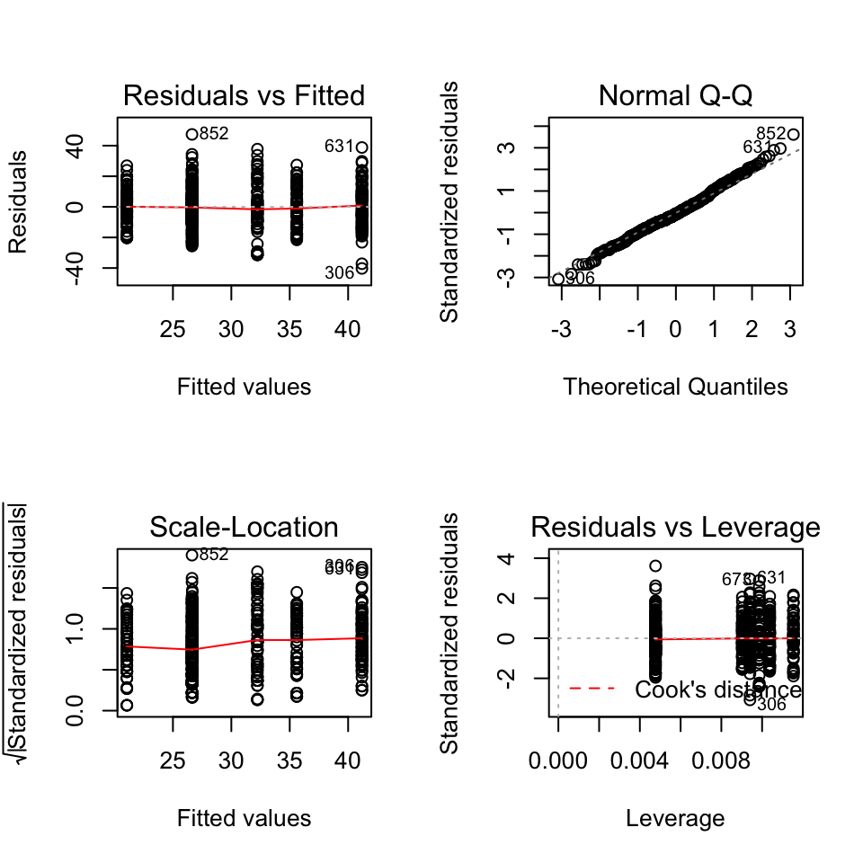

```r
plot(lmAge)[2]
```

```r
plot(lmAge)[3]
```

```r
plot(lmAge)[4]
```

This model is just OK, but we don’t need the perfect model for this type of imputation. Nice to see that both variance and normality assumptions of the model holds and all levels of the covariates have significant impact on the mean outcome in the presence of each other. This would give us a good estimation for the missing values of Age.

Using the model to impute missing values of Age:

```r
training$Age[is.na(training$Age)] = predict(lmAge, newdata = training[is.na(training$Age),])
tune.test.set$Age[is.na(tune.test.set$Age)] = predict(lmAge, newdata = tune.test.set[is.na(tune.test.set$Age),])
testing$Age[is.na(testing$Age)] = predict(lmAge, newdata = testing[is.na(testing$Age),])
```

Note that we use the same model object we derived from the training data set to impute the missing values of Age for all data sets. This will prevent us from overfitting to the test data set.

Re-investigate the missing values:

```r
training.na <- as.data.frame(is.na(training));names(training.na) <- names(training)
apply(training.na,2,sum)
```

```
## Survived   Pclass     Name      Sex      Age    SibSp    Parch   Ticket
##        0        0        0        0        0        0        0        0
##     Fare Embarked
##        0        1
```

```r
tune.testing.na <- as.data.frame(is.na(tune.test.set));names(tune.testing.na) <- names(tune.test.set)
apply(tune.testing.na ,2,sum)
```

```
## Survived   Pclass     Name      Sex      Age    SibSp    Parch   Ticket
##        0        0        0        0        0        0        0        0
##     Fare Embarked
##        0        1
```

```r
testing.na <- as.data.frame(is.na(testing));names(testing.na) <- names(testing)
apply(testing.na ,2,sum)
```

```
## PassengerId      Pclass        Name         Sex         Age       SibSp
##           0           0           0           0           0           0
##       Parch      Ticket        Fare    Embarked
##           0           0           1           0
```

It appears that only one case is left missing in each of the data sets. We will consider this as random missingness and remove in each data set:

```r
training <- training[complete.cases(training),]
tune.test.set <- tune.test.set[complete.cases(tune.test.set),]
testing <- testing[complete.cases(testing),]
```

Now we have completed processing the missing values.

# Feature Engineering:

## Generate Dummy Variables with Factor variables

Better to perform this step at the very end for all categorical variables.

```r
library(caret)

which(sapply(training[,-1],is.factor))
```

```
##   Pclass      Sex    SibSp    Parch Embarked
##        1        3        5        6        9
```

```r
# There are 5 categorical predictors in out data set

factors.training <- which(sapply(training,is.factor))
factors.tune.test.set <- which(sapply(tune.test.set,is.factor))
factors.testing <- which(sapply(testing,is.factor))


dummies.training <- dummyVars(Survived ~ Pclass + Sex + SibSp + Parch + Embarked, data = training)

dummies.tune.test.set <- dummyVars(Survived ~ Pclass + Sex + SibSp + Parch + Embarked, data = tune.test.set)

dummies.testing <- dummyVars(PassengerId ~ Pclass + Sex + SibSp + Parch + Embarked, data = testing)


# Add the dummy variables to both training and test data sets, simultaneously removing the existing factor variables:
training <- cbind(training[,-factors.training[-1]], predict(dummies.training,newdata = training))
tune.test.set <- cbind(tune.test.set[,-factors.tune.test.set[-1]], predict(dummies.tune.test.set,newdata = tune.test.set))
testing <- cbind(testing[,-factors.testing], predict(dummies.testing,newdata = testing))
```

After doing that we notice that there are differences in the factor levels of certain variables are not present in the training set and test sets. These are present in Parch and SibSp features. The lower levels of these variables are conserved in all sets and they represent most of the data. At this stage we will only keep features that are present in all sets:

```r
training <- training[,names(training) %in% names(tune.test.set)]
tune.test.set <- tune.test.set[,names(tune.test.set) %in% names(training)]

identical(names(training),names(tune.test.set))
```

```
## [1] TRUE
```

```r
PassengerId <- testing$PassengerId

testing <- testing[,names(testing) %in% names(training)]
testing$PassengerId <- PassengerId
```

### Feature engineering with Name and Ticket variables

### Ticket feature:

It would be interesting to just convert the ticket feature to numeric and see if it has any seperation value:

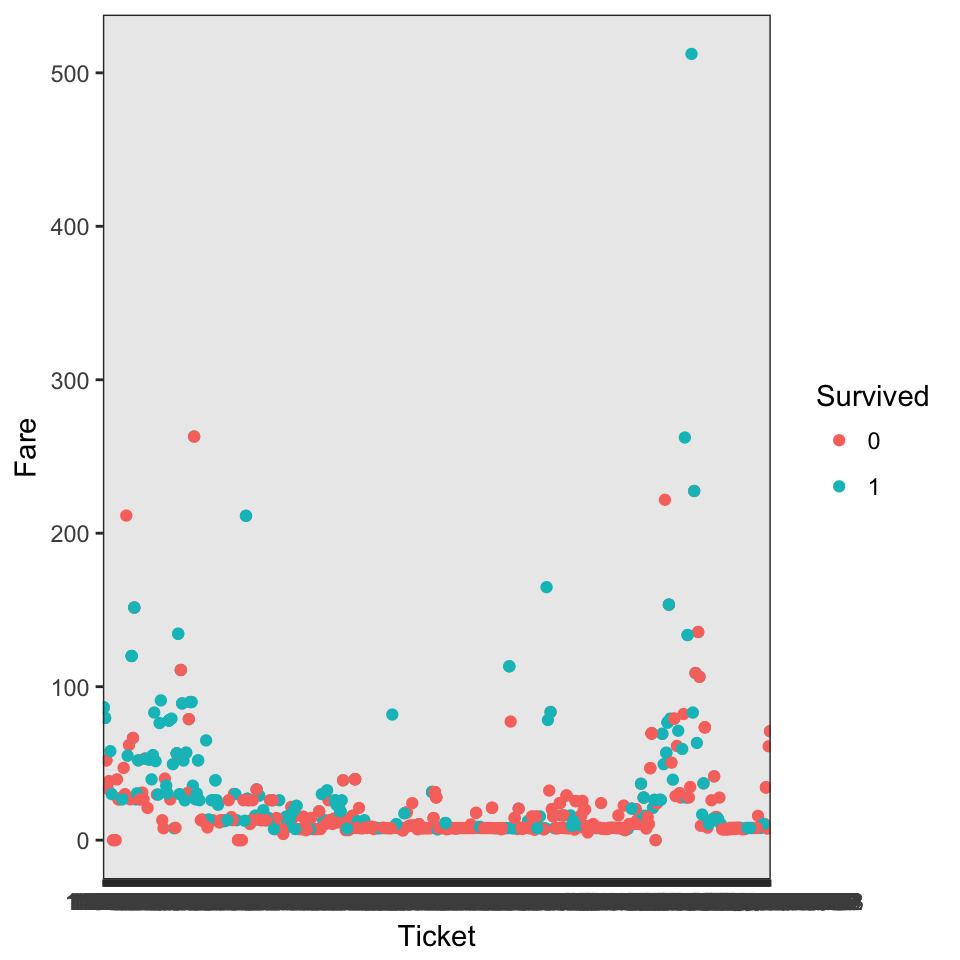

```r
Ticket <- toupper(training$Ticket)
# Better to remove anything left of the last white space
w <- grep(" ", Ticket)
last.space<- sapply(gregexpr(" ",Ticket[w]), function(y){
        max(y[1])
})

Ticket[w] <- substring(Ticket[w],last.space+1)

Ticket <- gsub(" ","", Ticket)
Ticket <- gsub("[A-Z]","",Ticket)
Ticket <- gsub("\\.","",Ticket)
Ticket <- gsub("\\/","", Ticket)
Ticket <- as.numeric(Ticket)
Ticket[is.na(Ticket)] = 0
Ticket <- as.numeric(Ticket)


qplot(x=Ticket, y = Fare, data = training, color = Survived)+theme_bw()
```

We note that at least two groups of ticket numbers are associated with higher fares, and to some extent they seperate the outcome classes. Therefore, we will engineer this numeric feature and add into all sets, we will remove the original variable.

```r
# Feature Engineering function

num.Ticket <- function(x){
Ticket <- toupper(x$Ticket)
# Better to remove anything left of the last white space
w <- grep(" ", Ticket)
last.space<- sapply(gregexpr(" ",Ticket[w]), function(y){
        max(y[1])
})
Ticket[w] <- substring(Ticket[w],last.space+1)

Ticket <- gsub(" ","", Ticket)
Ticket <- gsub("[A-Z]","",Ticket)
Ticket <- gsub("\\.","",Ticket)
Ticket <- gsub("\\/","", Ticket)
Ticket <- as.numeric(Ticket)
Ticket <- as.numeric(Ticket)
return(Ticket)
}

training$num.Ticket <- num.Ticket(training)
tune.test.set$num.Ticket <- num.Ticket(tune.test.set)
testing$num.Ticket <- num.Ticket(testing)


sum(is.na(training$num.Ticket ))
```

```
## [1] 2
```

```r
sum(is.na(tune.test.set$num.Ticket ))
```

```
## [1] 2
```

```r
sum(is.na(testing$num.Ticket))
```

```
## [1] 0
```

After this conversion, only 2 missing values were introduced to training and tune.testing data sets.

### Name feature:

When looking into the names of the passengers, we notice that at least we can attempt to extract a “title” feature from the name strings and explore its relationship with the outcome:

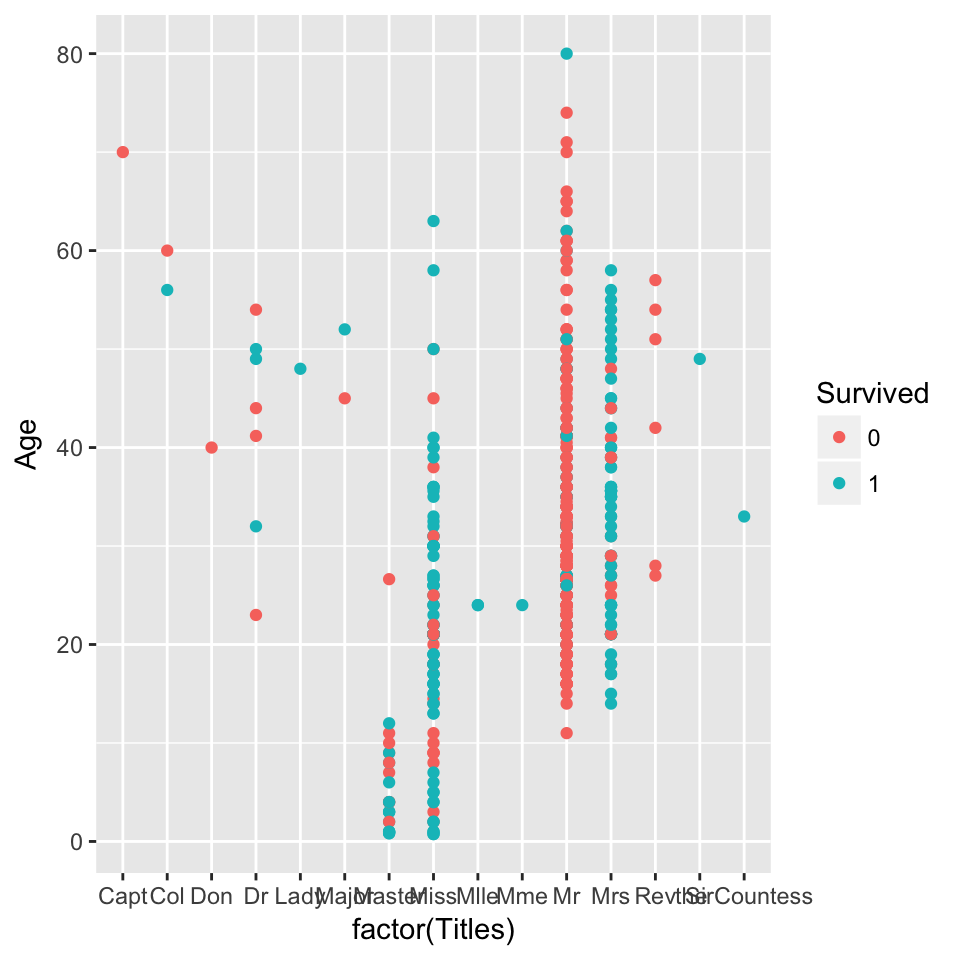

```r
Pass.Names <- training$Name

first.comma<- sapply(gregexpr(",",Pass.Names), function(y){
        y[1][1]
})
first.dot <- sapply(gregexpr("\\.",Pass.Names), function(y){
        y[1][1]
})

Titles <- substr(Pass.Names,first.comma+2,first.dot-1)

qplot(x = factor(Titles), y = Age ,color = Survived, data = training)
```

This feature can also be useful, therefore we will add into the data sets:

```r
# Feature engineering function:
Titles <- function(x){
      Pass.Names <- x$Name

first.comma<- sapply(gregexpr(",",Pass.Names), function(y){
        y[1][1]
})
first.dot <- sapply(gregexpr("\\.",Pass.Names), function(y){
        y[1][1]
})

Titles <- substr(Pass.Names,first.comma+2,first.dot-1)
return(Titles)

}

training$Titles <- factor(Titles(training))
tune.test.set$Titles <- factor(Titles(tune.test.set))
testing$Titles <- factor(Titles(testing))
```

Next, we need to create dummy variables from each of these titles:

```r
factors.training <- which(sapply(training,is.factor))
factors.tune.test.set <- which(sapply(tune.test.set,is.factor))
factors.testing <- which(sapply(testing,is.factor))


dummies.training <- dummyVars(Survived ~ Titles, data = training)

dummies.tune.test.set <- dummyVars(Survived ~ Titles, data = tune.test.set)

dummies.testing <- dummyVars(PassengerId ~ Titles, data = testing)
```

# Add the dummy variables to both training and test data sets, simultaneously removing the existing factor variables:

```r
training <- cbind(training[,-factors.training[-1]], predict(dummies.training,newdata = training))
tune.test.set <- cbind(tune.test.set[,-factors.tune.test.set[-1]], predict(dummies.tune.test.set,newdata = tune.test.set))
testing <- cbind(testing[,-factors.testing], predict(dummies.testing,newdata = testing))
```

Not surprisingly ,after doing that we notice that there are differences in the factor levels of Titles feature. At this stage we will only keep features that are present in all sets:

```r
training <- training[,names(training) %in% names(tune.test.set)]
tune.test.set <- tune.test.set[,names(tune.test.set) %in% names(training)]

identical(names(training),names(tune.test.set))
```

```
## [1] TRUE
```

```r
PassengerId <- testing$PassengerId

testing <- testing[,names(testing) %in% names(training)]
testing$PassengerId <- PassengerId
```

We should also remove the original Ticket and Name features from all data sets since we already have the engineered versions included:

```r
training <- dplyr::select(training,-Ticket,-Name)
tune.test.set <- dplyr::select(tune.test.set ,-Ticket,-Name)
testing <- dplyr::select(testing,-Ticket,-Name)
```

Finally, since we had 2 missing values we generated due to the Ticket feature engineering, we need to get the complete cases in each of the data set:

```r
training <- training[complete.cases(training),]
tune.test.set <- tune.test.set[complete.cases(tune.test.set),]
testing <- testing[complete.cases(testing),]

testing <- data.frame(PassengerId = testing$PassengerId, testing[,-27])
```

This completes the feature engineering for all data sets.

## Collinearity, Near Zero Variance and Dimension Reduction

# Remove near-zero variance features:

Once completed the feature engineering, let’s explore if there are near zero variance features in the training data set:

```r
nsv <- nearZeroVar(x = training, saveMetrics = TRUE)
sum(!nsv$nzv)
```

```
## [1] 20
```

20 out of the 27 variables have non-zero variance and will be kept in the data sets.

```r
training <- training[,!nsv$nzv]
tune.test.set <- tune.test.set[,!nsv$nzv]
testing <- testing[,!nsv$nzv]
```

## Test for high correlation:

```r
M <- abs(cor(training[,-1])) # M is an absolute value correlation matrix representing the pairwise #correlations between all variables
diag(M) <- 0 # We replace the diagonal values with zero (just because these are the correations with  #themselves we are not interested in capturing them).
which(M > 0.8, arr.ind = TRUE) # What are the highest correated variables?
```

```
##            row col
## Sex.male     7   6
## Titles.Mr   18   6
## Sex.female   6   7
## Titles.Mr   18   7
## SibSp.1      9   8
## SibSp.0      8   9
## Sex.female   6  18
## Sex.male     7  18
```

```r
unique(row.names(which(M > 0.8, arr.ind = TRUE)))
```

```
## [1] "Sex.male"   "Titles.Mr"  "Sex.female" "SibSp.1"    "SibSp.0"
```

```r
cor.variables <- training[,unique(row.names(which(M > 0.8, arr.ind = TRUE)))]
cor.variables$Survived <- training$Survived
```

## Principal components analysis

Next we will perform PCA to see if dimension reduction might help to reduce the highly correlated predictors in the data set:

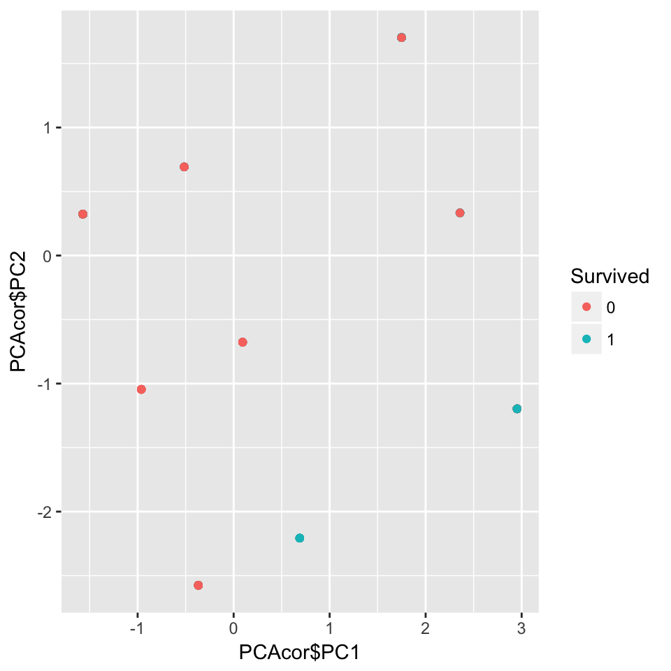

```r
prePCA <- preProcess(cor.variables[,-6],method = "pca")
PCAcor <- predict(prePCA,cor.variables[,-6])
qplot(PCAcor$PC1,PCAcor$PC2, color = Survived, data = cor.variables)
```

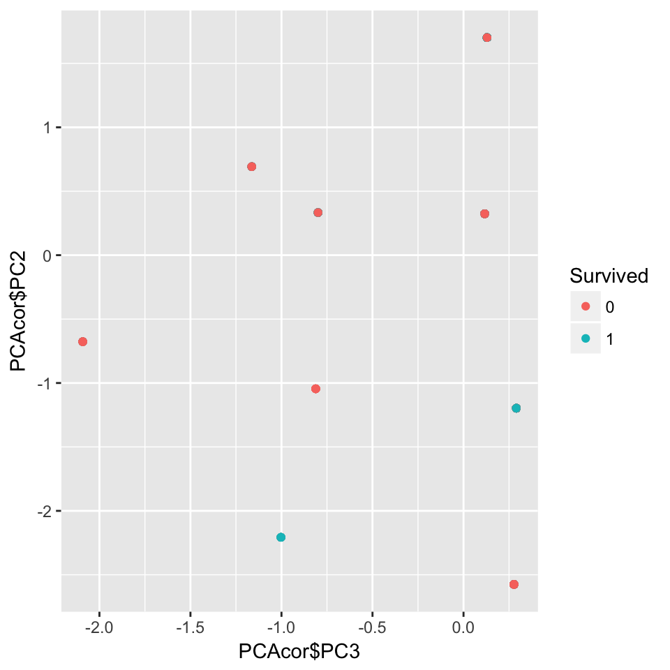

```r
qplot(PCAcor$PC3,PCAcor$PC2, color = Survived, data = cor.variables)
```

Since these are all binary variables, PCA did not furher help to reduce the dimensions.

We will use the remaining 20 features to train our classifiers.

## Training Classifiers

Due to the classification nature of the problem, we will perform tree-based prediction algorithms and support vector machines to perform predictions.

- Simple classification tree (method = “rpart”) with cross validation

```r
set.seed(125745)
RPART <- train(Survived ~ ., data = training,method = "rpart", trControl = trainControl(method = "cv", number = 10))
saveRDS(RPART,"RPART.rds") #Save model object for future loading if necessary
```

- Random Forest (method = “rf”) with cross validation

```r
set.seed(125745)
RF <- train(Survived ~ ., data = training,method = "rf", trControl = trainControl(method = "cv", number = 10))
saveRDS(RF,"RF.rds") #Save model object for future loading if necessary
```

- Boosted tree (method = “gbm”) with cross validation

```r
set.seed(125745)
GBM <- train(Survived ~ ., data = training,method = "gbm", trControl = trainControl(method = "cv", number = 10), verbose = FALSE)
saveRDS(GBM,"GBM.rds") #Save model object for future loading if necessary
```

- support vector machines with a radial kernel

```r
set.seed(125745)
SVM <- train(Survived ~ ., data = training,method = "svmRadial", trControl = trainControl(method = "cv", number = 10))
# Takes very long time to run!!
saveRDS(SVM,"SVM.rds")
```

# Summarizing the initial results from the individual classifiers

```r
# Using resamples function from the caret package to summarize the data

modelsummary <- resamples(list(RPART=RPART,RF=RF,GBM=GBM,SVM=SVM))

# In-sample accuracy values for each model
summary(modelsummary)$statistics$Accuracy
```

```
##         Min. 1st Qu. Median   Mean 3rd Qu.   Max. NA's
## RPART 0.7619  0.7849 0.8065 0.8118  0.8327 0.8689    0
## RF    0.7581  0.7890 0.8306 0.8248  0.8566 0.8852    0
## GBM   0.7581  0.7823 0.8161 0.8198  0.8497 0.9016    0
## SVM   0.7903  0.8065 0.8175 0.8181  0.8334 0.8548    0
```

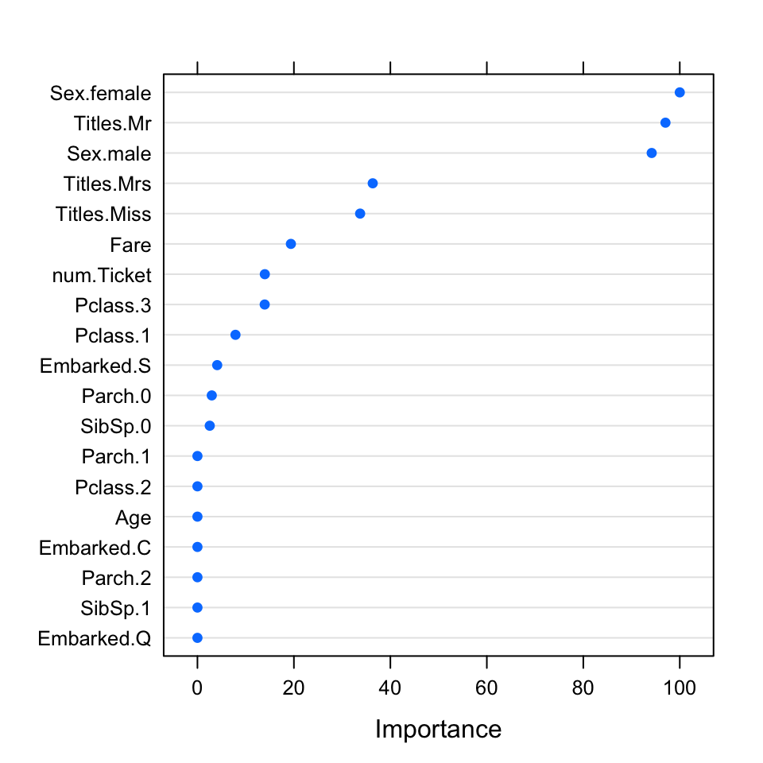

```r
# If necessary we can also produce 'variable importance' plots to see which variables are making most contributions #to each model
dotPlot(varImp(RPART))
```

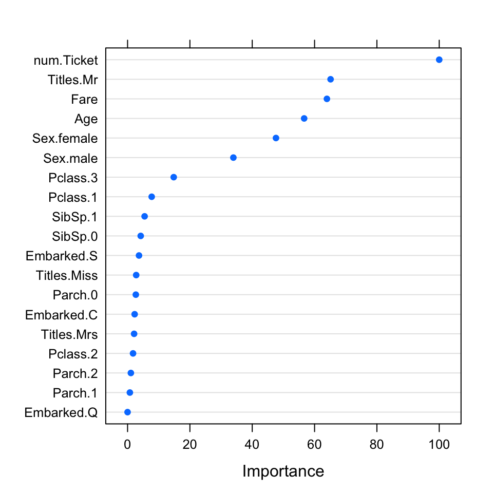

```r
dotPlot(varImp(RF))
```

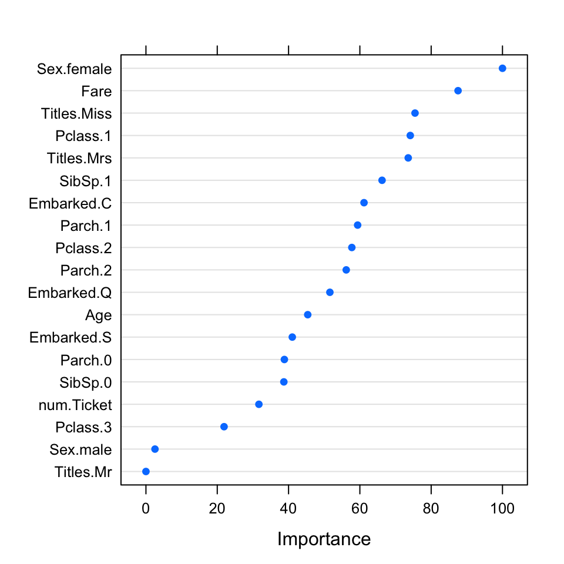

```r
dotPlot(varImp(SVM))
```

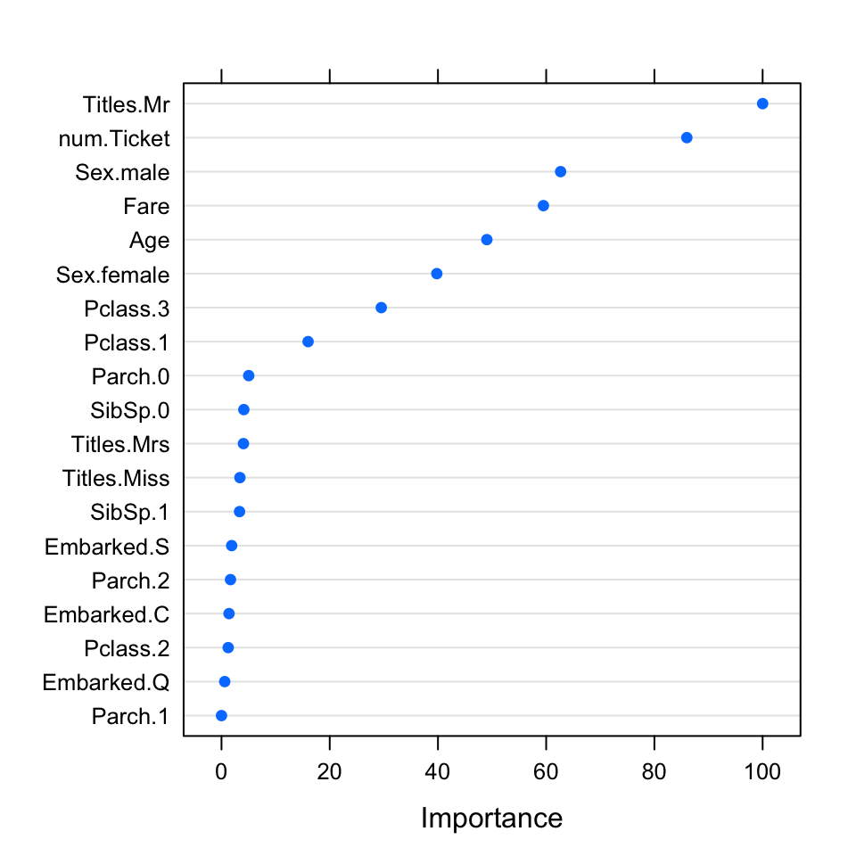

```r
dotPlot(varImp(GBM))
```

# Making predictions by using the classifiers and tune.test.set

```r
pred.tune.RPART <- predict(RPART,newdata = tune.test.set)
pred.tune.RF <- predict(RF,newdata = tune.test.set)
pred.tune.SVM <- predict(SVM,newdata = tune.test.set)
pred.tune.GBM <- predict(GBM,newdata = tune.test.set)

# Collect accuracy values in a data.frame:

tune.testing.predictions <-data.frame(pred.tune.RPART,pred.tune.RF,pred.tune.SVM,pred.tune.GBM)

tune.testing.accuracy <- apply(tune.testing.predictions, 2, function(x){
        temp=confusionMatrix(x,tune.test.set$Survived)$overall[1]
        names(temp) <- names(x)
        return(temp)
})
tune.testing.accuracy
```

```
## pred.tune.RPART    pred.tune.RF   pred.tune.SVM   pred.tune.GBM
##       0.8106061       0.8333333       0.7992424       0.7954545
```

Based on the prediction in the tune.test.set, Random Forest classification tree gave the highest out of the box accuracy. The accuracy is ~ 83.3 %.

### What if we had used dimension reduction?

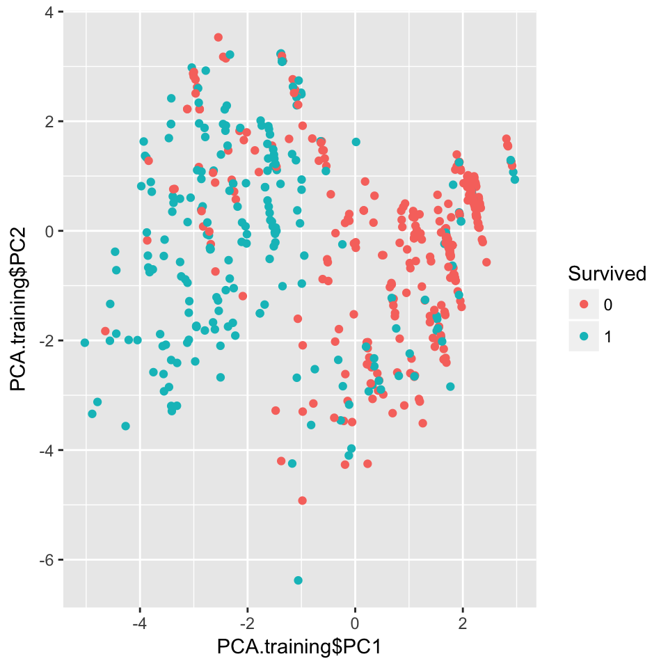

```r
prePCA.training <- preProcess(training[,-1],method = "pca")
PCA.training <- predict(prePCA.training,training[,-1])
PCA.training$Survived <- training$Survived
qplot(PCA.training$PC1,PCA.training$PC2, color = Survived, data = PCA.training)
```

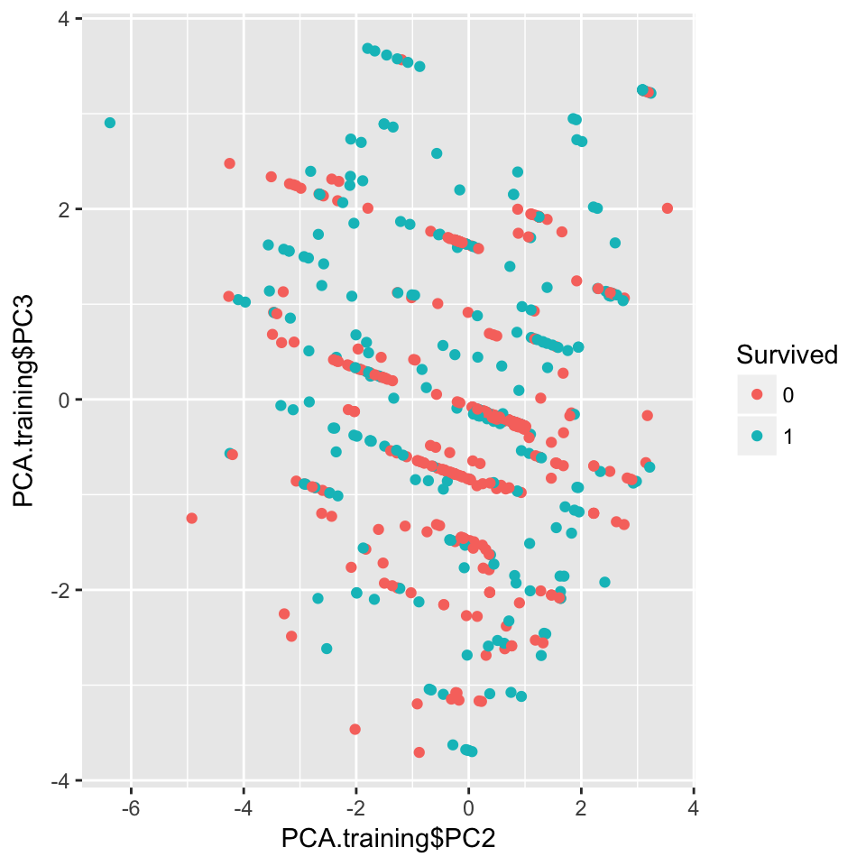

```r
qplot(PCA.training$PC2,PCA.training$PC3, color = Survived, data = PCA.training)
```

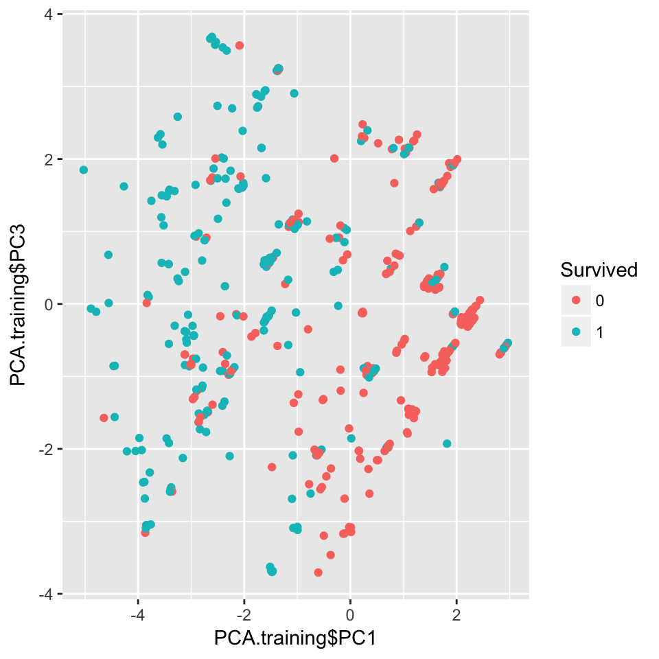

```r
qplot(PCA.training$PC1,PCA.training$PC3, color = Survived, data = PCA.training)
```

The seperation is indeed quite good.

Let’s try to fit models by using the Principal components, instead of the original data:

- Simple classification tree (method = “rpart”) with cross validation

```r
set.seed(125745)
RPART.PCA <- train(Survived ~ ., data = PCA.training,method = "rpart", trControl = trainControl(method = "cv", number = 10))
saveRDS(RPART.PCA,"RPART.PCA.rds") #Save model object for future loading if necessary
```

- Random Forest (method = “rf”) with cross validation

```r
set.seed(125745)
RF.PCA <- train(Survived ~ ., data = PCA.training,method = "rf", trControl = trainControl(method = "cv", number = 10))
saveRDS(RF.PCA,"RF.PCA.rds") #Save model object for future loading if necessary
```

- Boosted tree (method = “gbm”) with cross validation

```r
set.seed(125745)
GBM.PCA <- train(Survived ~ ., data = PCA.training,method = "gbm", trControl = trainControl(method = "cv", number = 10), verbose = FALSE)
saveRDS(GBM.PCA,"GBM.PCA.rds") #Save model object for future loading if necessary
```

- support vector machines with a radial kernel

```r
set.seed(125745)
SVM.PCA <- train(Survived ~ ., data = PCA.training,method = "svmRadial", trControl = trainControl(method = "cv", number = 10))
# Takes very long time to run!!
saveRDS(SVM.PCA,"SVM.PCA.rds")
```

```r
# Using resamples function from the caret package to summarize the data

modelsummary.PCA <- resamples(list(RPART=RPART.PCA,RF=RF.PCA,GBM=GBM.PCA,SVM=SVM.PCA))

# In-sample accuracy values for each model
summary(modelsummary.PCA)$statistics$Accuracy
```

```
##         Min. 1st Qu. Median   Mean 3rd Qu.   Max. NA's
## RPART 0.7581  0.7809 0.8159 0.8165  0.8484 0.8730    0
## RF    0.6935  0.7742 0.7823 0.7746  0.7937 0.8033    0
## GBM   0.7903  0.7961 0.8080 0.8116  0.8219 0.8548    0
## SVM   0.7419  0.7912 0.8001 0.8084  0.8361 0.8571    0
```

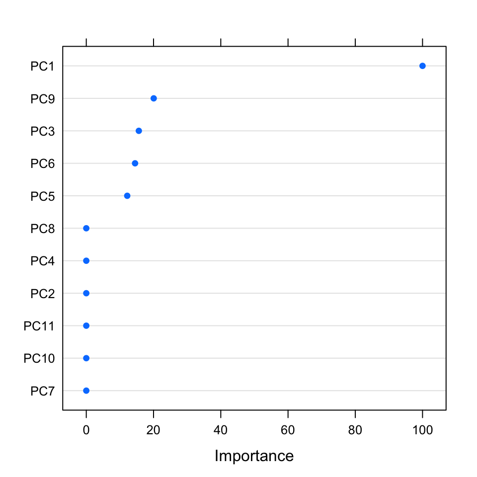

```r
# If necessary we can also produce 'variable importance' plots to see which variables are making most contributions #to each model
dotPlot(varImp(RPART.PCA))
```

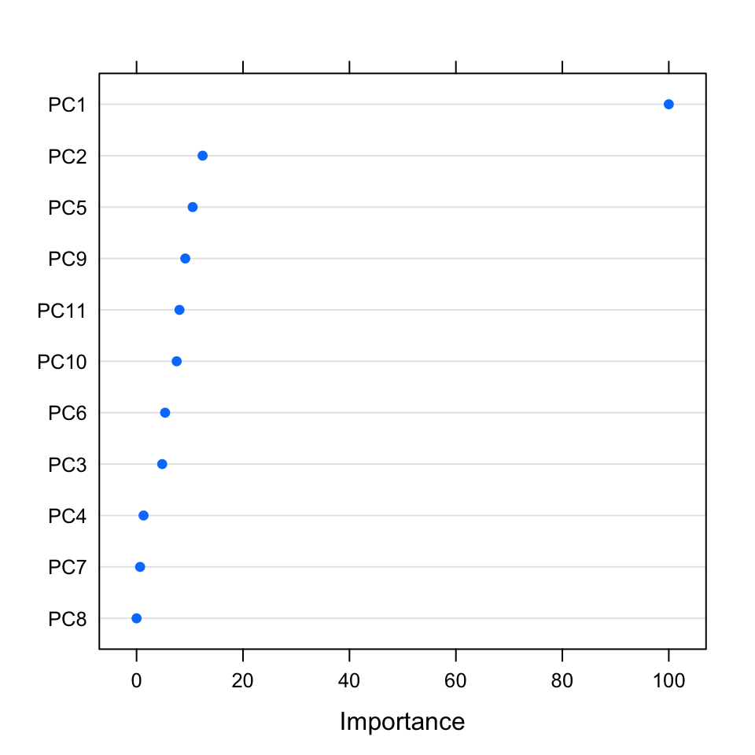

```r
dotPlot(varImp(RF.PCA))
```

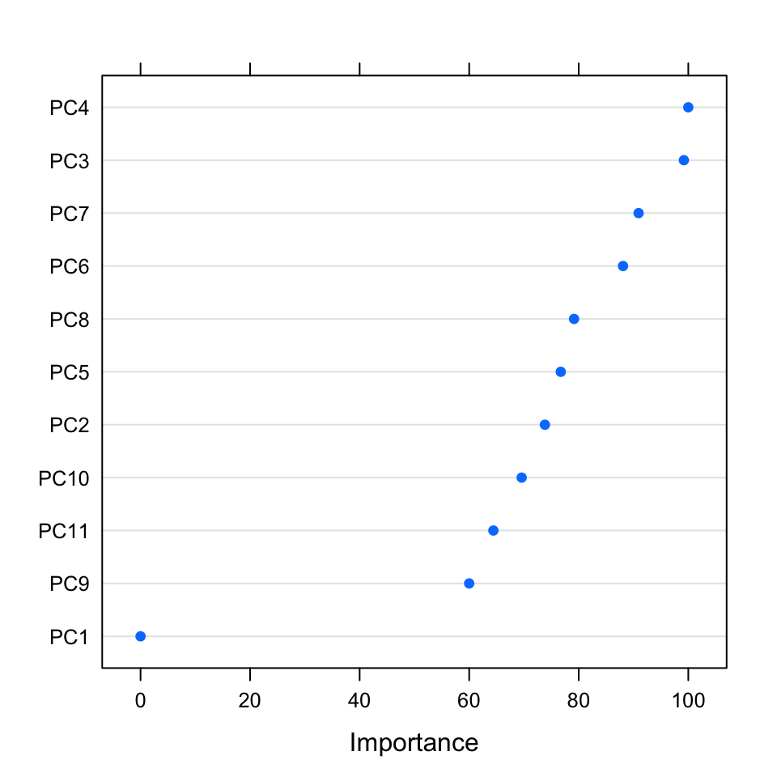

```r
dotPlot(varImp(SVM.PCA))
```

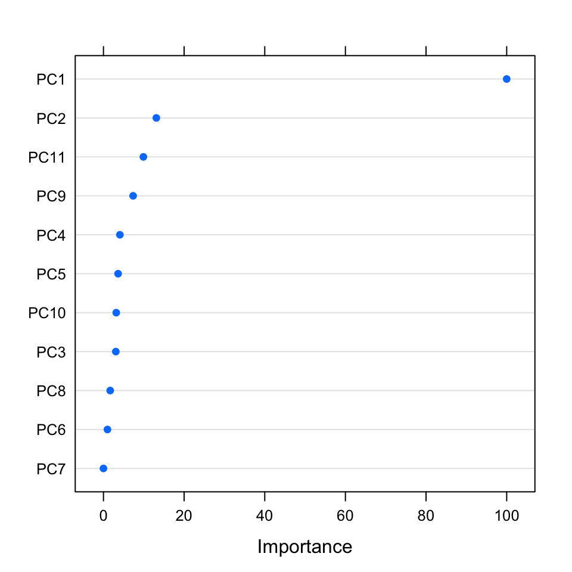

```r
dotPlot(varImp(GBM.PCA))
```

Not so much improvement of in sample accuracy.

What happens if we had only used the first 3 PCs?

- Simple classification tree (method = “rpart”) with cross validation

```r
set.seed(125745)
RPART.PCA3 <- train(Survived ~ PC1 + PC2 + PC3 , data = PCA.training,method = "rpart", trControl = trainControl(method = "cv", number = 10))
saveRDS(RPART.PCA3,"RPART.PCA3.rds") #Save model object for future loading if necessary
```

- Random forest with cross validation

```r
set.seed(125745)
RF.PCA3 <- train(Survived ~ PC1 + PC2 + PC3 , data = PCA.training,method = "rf", trControl = trainControl(method = "cv", number = 10))
saveRDS(RF.PCA3,"RF.PCA3.rds") #Save model object for future loading if necessary
```

# Stepping back

What if we didn’t perform extensive feature engineering?:

```r
logit.training <- glm(Survived ~ . , data = training, family = "binomial")
summary(logit.training)
```

```
##
## Call:
## glm(formula = Survived ~ ., family = "binomial", data = training)
##
## Deviance Residuals:
##     Min       1Q   Median       3Q      Max
## -2.7132  -0.5574  -0.3436   0.5471   2.4924
##
## Coefficients: (3 not defined because of singularities)
##               Estimate Std. Error z value Pr(>|z|)
## (Intercept) -2.315e+00  9.278e-01  -2.495 0.012599 *
## Age         -4.309e-02  1.139e-02  -3.783 0.000155 ***
## Fare         2.998e-03  3.348e-03   0.895 0.370524
## Pclass.1     2.586e+00  4.330e-01   5.973 2.33e-09 ***
## Pclass.2     1.256e+00  3.189e-01   3.940 8.14e-05 ***
## Pclass.3            NA         NA      NA       NA
## Sex.female   1.435e+01  5.779e+02   0.025 0.980188
## Sex.male            NA         NA      NA       NA
## SibSp.0      1.249e+00  4.783e-01   2.611 0.009030 **
## SibSp.1      1.265e+00  4.884e-01   2.591 0.009572 **
## Parch.0      9.923e-01  7.467e-01   1.329 0.183880
## Parch.1      1.015e+00  7.839e-01   1.295 0.195327
## Parch.2      6.890e-01  8.210e-01   0.839 0.401297
## Embarked.C   1.094e-01  3.075e-01   0.356 0.721993
## Embarked.Q   2.041e-01  4.317e-01   0.473 0.636262
## Embarked.S          NA         NA      NA       NA
## num.Ticket   1.074e-07  2.860e-08   3.756 0.000172 ***
## Titles.Miss -1.301e+01  5.779e+02  -0.023 0.982038
## Titles.Mr   -1.603e+00  4.145e-01  -3.867 0.000110 ***
## Titles.Mrs  -1.231e+01  5.779e+02  -0.021 0.983004
## ---
## Signif. codes:  0 '***' 0.001 '**' 0.01 '*' 0.05 '.' 0.1 ' ' 1
##
## (Dispersion parameter for binomial family taken to be 1)
##
##     Null deviance: 825.76  on 620  degrees of freedom
## Residual deviance: 496.49  on 604  degrees of freedom
## AIC: 530.49
##
## Number of Fisher Scoring iterations: 14
```